# Convolutional Neural Networks

[Nic Lane](http://niclane.org/)

2022-02-10

## Plan for the Day

- **Introduction**
  - **Inductive bias**
  - **Inductive bias in NNs**
- Convolutional operator
  - Translation invariance in images
  - Convolutional Neural Networks
- Advanced convolution variants
  - Parameter-free convolution
  - Depth-wise separability & shuffle
  - Deconvolution & super resolution
  - Graph CNNs

## Inductive bias

What is inductive bias?

- An assumption that allows the model to make predictions about never-seen data.
- All models carry one form of an inductive bias or other.
  - i.e.: linear model, nonlinear model, type of non-linearity...

Why do we need it?

- Data is expensive to gather or generate.
- Data is sparse - usually, we observe only a sample of the true data population.
- Generalization is *necessary* for both academic and industrial use of (deep) models.

## Inductive bias

[figure not shown]

## Inductive bias in NNs

*A simple universal approximator that makes no assumptions about its input structure.*

[figure not shown]

## Inductive bias in NNs

[figure not shown]

- Common to all NNs
  - Layered feature maps
    - Nodes within a layer are assumed never to interact
    - Inputs are processed on an directed acyclic graph
  - Gradient descent
    - Preference for models trainable by gradient
    - descent given the chosen initializer
    - Recall week 2: Optimization and Stochastic Gradient Descent
- Layer-specific inductive biases - relational inductive biases
  - **Locality: CNNs - preferred model is invariant to spatial translations**
  - Sequentiality: RNNs - preferred model is invariant to time translations
  - Arbitrary: Graph NNs - preferred model is invariant to node & edge permutations

## Inductive bias in NNs

- **Plain English:** An inductive bias allows a learning algorithm to prioritize one solution (or interpretation) over another, independent of the observed data.
- **Bayesian perspective:** inductive biases are captured by the model’s prior distribution. In this context, the specific shoice of an NN architecture can be seen as an extreme choice of a prior.

  $$\large p(\theta\|X,Y)= \huge
  \frac{p(Y|X,\theta) p(\theta)}{p(Y|X)}$$
- **Technical perspective:** all NN layers can be seen as special cases of fully connected layers. Inductive biases are expressed by the weight-sharing restrictions that define any given layer type.

## Plan for the day

- Introduction
  - Inductive bias
  - Inductive bias in NNs
- **Convolutional operator**
  - **Translation invariance in images**
  - **Convolutional Neural Networks**
- Advanced convolution variants
  - Parameter-free convolution
  - Depth-wise separability & shuffle
  - Deconvolution & super resolution
  - Graph CNNs

## Translation invariance in CNNs

## Convolutional Neural Networks

$$\large Out_{i,j}= b + \sum_{x=1}^3 \sum_{y=1}^3 In_{(i+x-1),(j+y-1)}W_{x,y}$$

| Image | Kernel | Output |
| --- | --- | --- |

## Convolutional Neural Networks

$$\large D_{out} = \huge \frac{(D_{in} - K + 2P)}{2} \large + 1$$

| Kernel size (3x3) | Stride (2) | Padding (1) |
| --- | --- | --- |

## Weight sharing in CNNs

## Numerical example of a CNN

[video not shown]

## Numerical example of a CNN - code

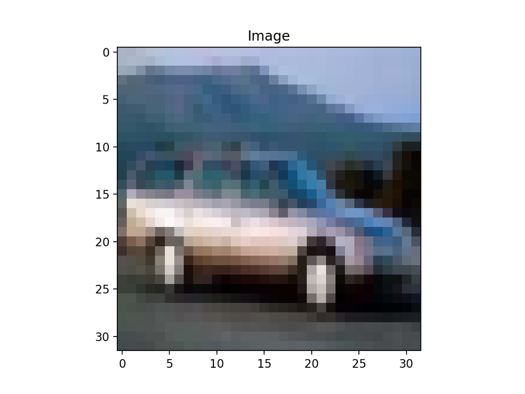

## Numerical example of a CNN - code

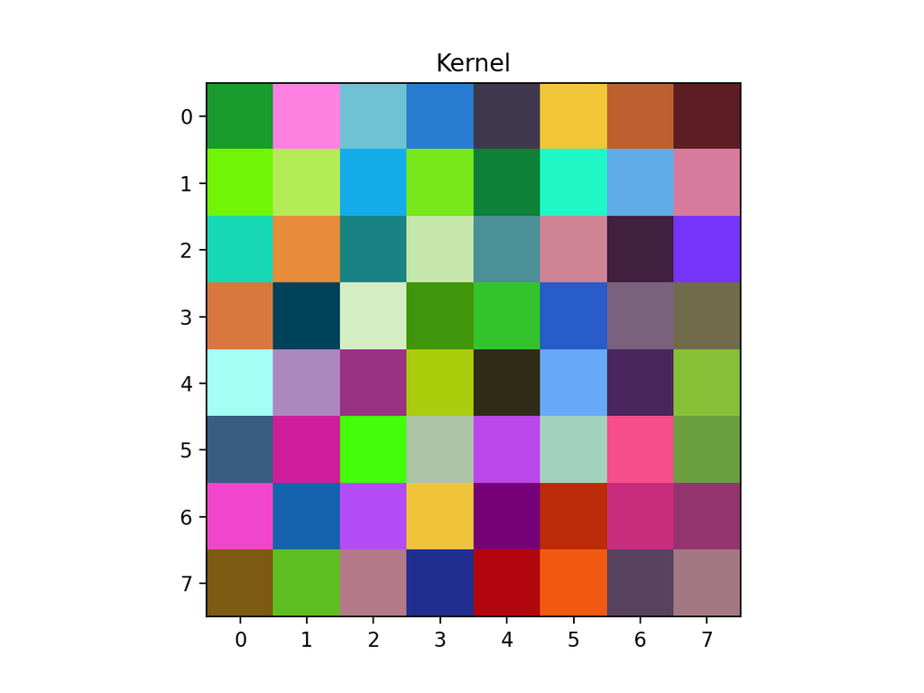

## Numerical example of a CNN - code

## CNN as an edge detector

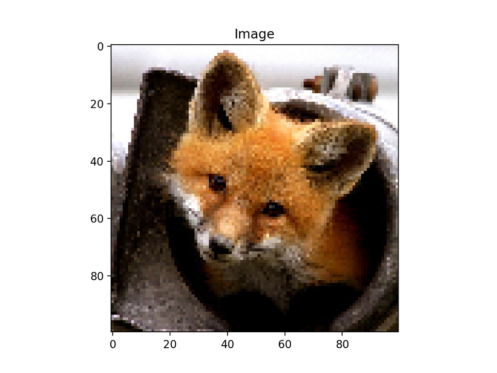